# Résultats des modèles d’apprentissage supervisé

# 1 Fonction pour les graphiques

```r
make_plot <- function(metric, boot_res_opt_df, boot_res_sum_opt_df) {
  lev <-
  c(
    "class",
    "class_dist",
    "class_dist_maha",
    "class_dist_local_lof",
    "class_dist_local_10_lof",
    "class_dist_global_10_lof",
    "class_dist_global_20_lof",
    "class_dist_global_30_lof",
    "class_dist_global_40_lof"
  )

  df1 <- filter(boot_res_opt_df, .metric == metric)
  df2 <- filter(boot_res_sum_opt_df, .metric == metric)

  ggplot(df1, aes(x = covariates, y = .estimate, color = covariates, fill = covariates)) +
    ggdist::stat_halfeye(
      adjust = .33,
      width = .67,
      color = NA,
      position = position_nudge(x = .1)
    ) +
    geom_point(aes(x = covariates, y = mean), data = df2) +
    geom_point(
      position = position_nudge(x = -.22),
      shape = 95, size = 4, alpha = 0.7
    ) +
    ylab(metric) +
    xlab(NULL) +
    guides(fill = "none", color = "none") +
    theme(axis.text.x = element_text(angle = 90, vjust = 0.5, hjust = 1))
}
```

# 2 Importer les résultats

```r
glmnet_tuning_ls <- tar_read(glmnet_tuning_ls)
rf_tuning_ls <- tar_read(rf_tuning_ls)
xgb_tuning_ls <- tar_read(xgb_tuning_ls)
```

```r
names(glmnet_tuning_ls) <- names(rf_tuning_ls) <- names(xgb_tuning_ls) <- names(tar_read(ml_df_ls))
```

```r
collect_optimal_metrics <- function(tuning, metric, summarize = T) {
  best_params <- select_best(tuning, metric = metric)
  tuning %>%
    filter_parameters(parameters = best_params) %>%
    collect_metrics(summarize = summarize)
}
```

```r
make_tuning_res_df <- function(tuning_ls, metric, summarize = T) {
  map(tuning_ls, collect_optimal_metrics, metric = metric, summarize = summarize) %>%
    imap_dfr(~ mutate(.x, covariates = .y))
}
```

```r
glmnet_res_sum <- make_tuning_res_df(glmnet_tuning_ls, metric = "roc_auc", summarize = T)
rf_res_sum <- make_tuning_res_df(rf_tuning_ls, metric = "roc_auc", summarize = T)
xgb_res_sum <- make_tuning_res_df(xgb_tuning_ls, metric = "roc_auc", summarize = T)

glmnet_res <- make_tuning_res_df(glmnet_tuning_ls, metric = "roc_auc", summarize = F)
rf_res <- make_tuning_res_df(rf_tuning_ls, metric = "roc_auc", summarize = F)
xgb_res <- make_tuning_res_df(xgb_tuning_ls, metric = "roc_auc", summarize = F)
```

# 3 Graphiques de la performance des ensembles de prédicteurs

On a une base de données équilibrée (50% réclamants et 50% non-réclamants) de 4834 contrats d’un an (dont 30% est mis de côté pour l’ensemble test). Pour chaque contrat on a les variables classiques et la distance parcourue. J’ai calculé les LOFs globaux avec k = 10, k = 20, k = 30 et k = 40, ainsi que les LOFs locaux (k spécifique à chaque VIN déterminé avec l’algorithme de tuning, et k fixé à 10 pour tous) et le score de Mahalanobis. J’ai ensuite calculé des statistiques avec ces LOFs et score de Mahalanobis (moyenne, variance, skewness, etc.). On veut comparer la performance d’un elastic-net et d’un XGBoost avec et sans ces statistiques reliées aux LOFs (et score de Mahalanobis). On prend comme métriques l’AUC, l’accuracy, la sensibilité (capacité à bien détecter les réclamants) et la spécificité (capacité à bien détecter les non-réclamants).

- **class**: variables classiques seulement
- **class_dist**: variables classiques + distance parcourue
- **class_dist_maha**: variables classiques + distance parcourue + score de Mahalanobis
- **class_dist_local_lof**: variables classiques + distance parcourue + LOFs locaux calibré individuellement
- **class_dist_local_10_lof**: variables classiques + distance parcourue + LOFs locaux avec k = 10 pour tous
- **class_dist_global_10_lof**: variables classiques + distance parcourue + LOFs globaux avec k = 10
- **class_dist_global_20_lof**: variables classiques + distance parcourue + LOFs globaux avec k = 20
- **class_dist_global_30_lof**: variables classiques + distance parcourue + LOFs globaux avec k = 30
- **class_dist_global_40_lof**: variables classiques + distance parcourue + LOFs globaux avec k = 40

Les graphiques suivants montrent la distribution des 4 métriques pour 50 échantillons bootstrap (le bootstrap a été utilisé à la place de la validation croisée pour avoir une meilleure idée de la distribution). Les points correspondent à la métrique moyenne.

## 3.1 Modèles elastic-net

### 3.1.1 Performance avec 50 échantillons bootstrap

#### AUC

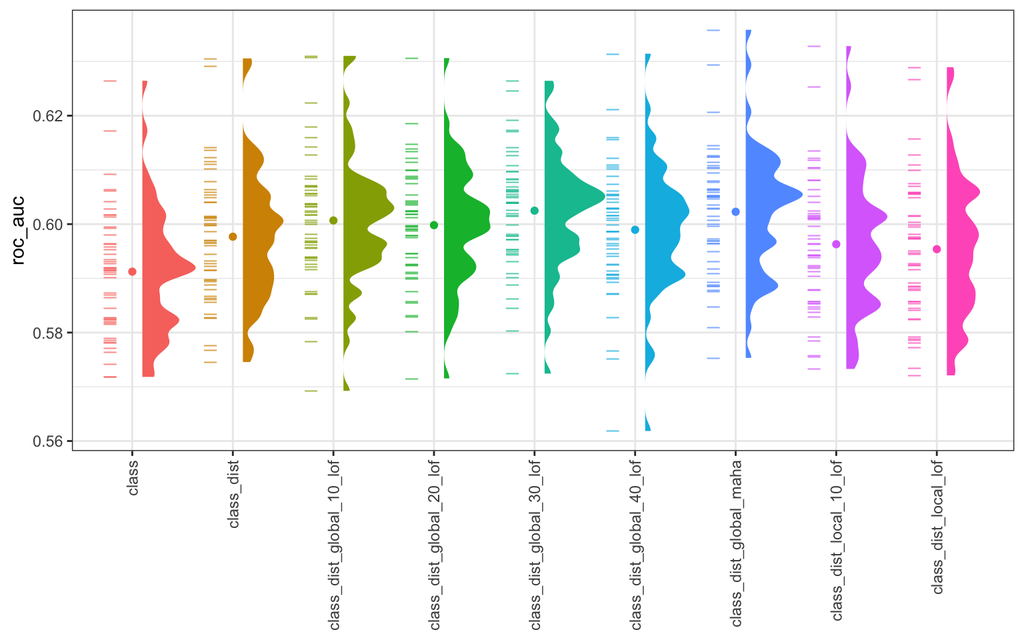

```r
make_plot("roc_auc", glmnet_res, glmnet_res_sum)
```

#### Accuracy

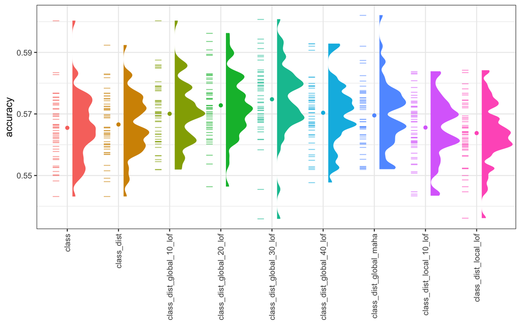

```r
make_plot("accuracy", glmnet_res, glmnet_res_sum)
```

#### Sensibilité

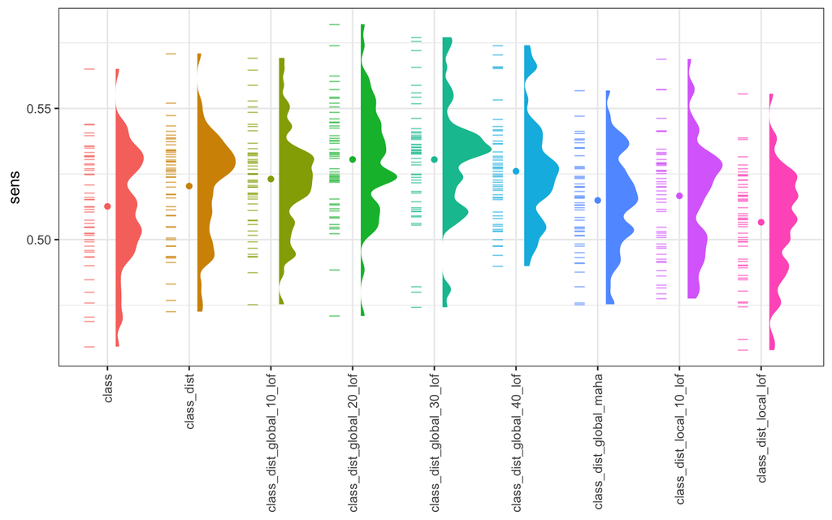

```r
make_plot("sens", glmnet_res, glmnet_res_sum)
```

#### Spécificité

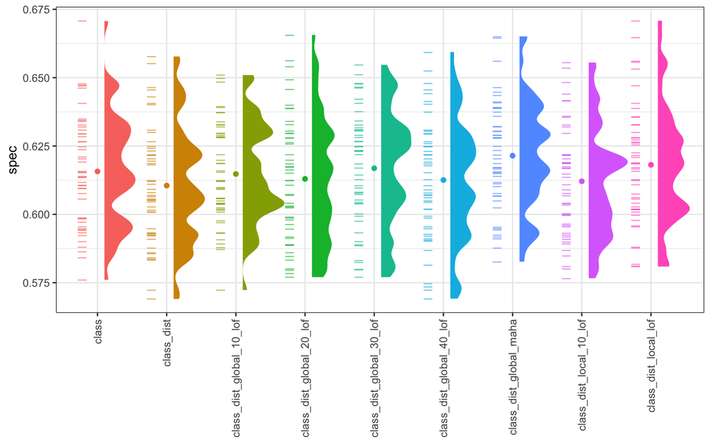

```r
make_plot("spec", glmnet_res, glmnet_res_sum)
```

### 3.1.2 Amélioration par rapport au modèle classique

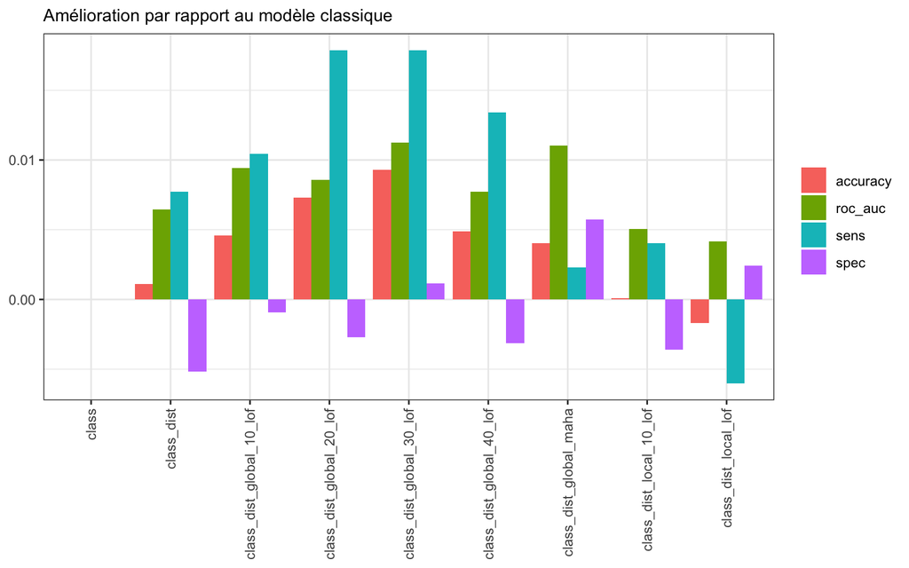

```r
glmnet_res_sum %>%
  group_split(.metric) %>%
  map(~ mutate(., amelioration = mean - first(mean))) %>%
  reduce(bind_rows) %>%
  ggplot(aes(y = amelioration, x = covariates, fill = .metric)) +
  geom_col(position = "dodge") +
  theme(axis.text.x = element_text(angle = 90, vjust = 0.5, hjust = 1)) +
  xlab(NULL) +
  ylab(NULL) +
  labs(fill = NULL, subtitle = "Amélioration par rapport au modèle classique")
```

### 3.1.3 Amélioration par rapport au modèle classique + distance

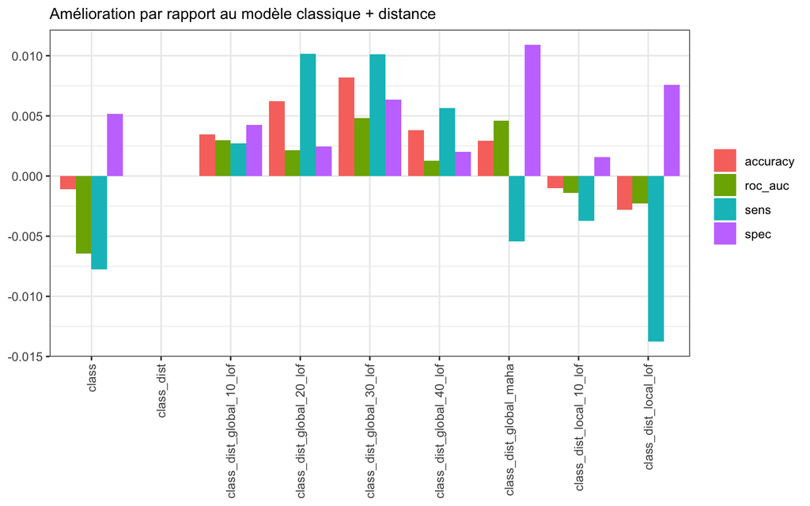

```r
glmnet_res_sum %>%
  group_split(.metric) %>%
  map(~ mutate(., amelioration = mean - nth(mean, 2))) %>%
  reduce(bind_rows) %>%
  ggplot(aes(y = amelioration, x = covariates, fill = .metric)) +
  geom_col(position = "dodge") +
  theme(axis.text.x = element_text(angle = 90, vjust = 0.5, hjust = 1)) +
  xlab(NULL) +
  ylab(NULL) +
  labs(fill = NULL, subtitle = "Amélioration par rapport au modèle classique + distance")
```

### 3.1.4 Analyse de l’importance des variables

```r
glmnet_ls <- tar_read(glmnet_ls)
glmnet_last_fit_ls <- map(glmnet_ls, "last_fit")
```

```r
plot_enet_coefs <- function(last_fit, title = NULL, subtitle = NULL) {
  last_fit %>%
    extract_fit_parsnip() %>%
    tidy() %>%
    filter(term != "(Intercept)") %>%
    mutate(Sign = if_else(estimate > 0, "+", "-")) %>%
    mutate(abs_estimate = abs(estimate)) %>%
    mutate(term = fct_reorder(term, abs_estimate)) %>%
    ggplot(aes(x = term, y = abs_estimate, fill = Sign)) +
    geom_col(alpha = 0.7) +
    xlab(NULL) +
    ylab("Absolute value of coefficient") +
    scale_fill_manual(values = c("#a61d21", "#00743F")) +
    coord_flip() +
    labs(subtitle = subtitle) +
    ggtitle(title)
}
```

#### class

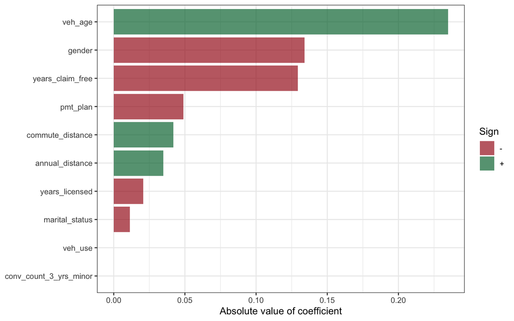

```r
plot_enet_coefs(glmnet_last_fit_ls[[1]])
```

#### class + dist

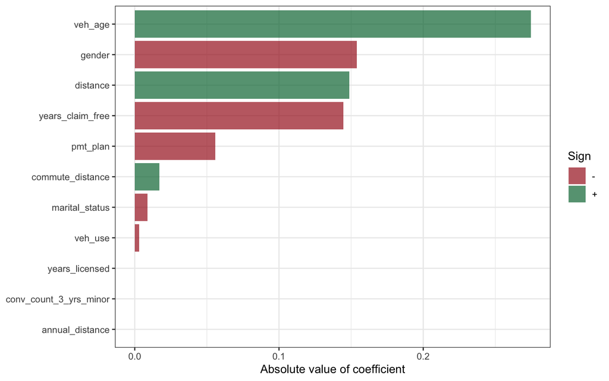

```r
plot_enet_coefs(glmnet_last_fit_ls[[2]])
```

#### class + dist + maha

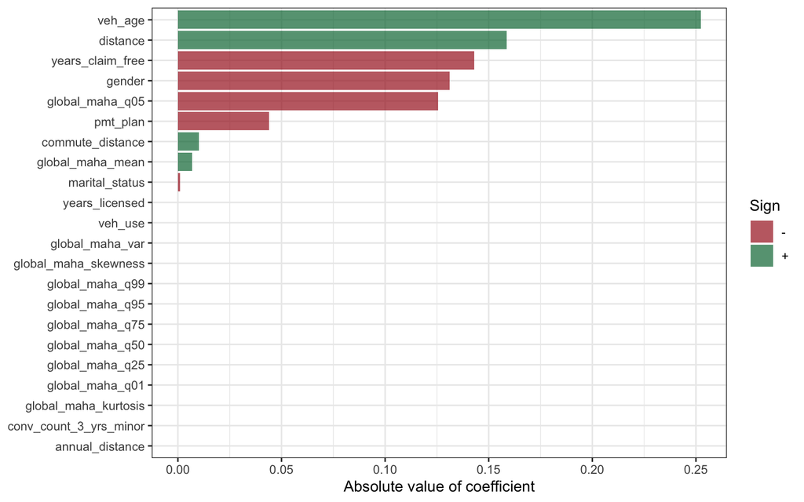

```r
plot_enet_coefs(glmnet_last_fit_ls[[3]])
```

#### class + dist + local_lof

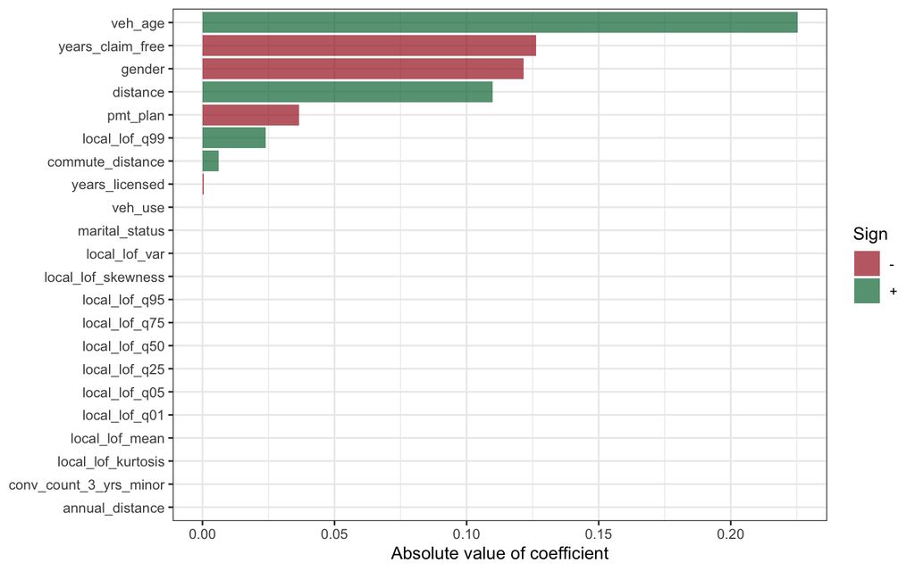

```r
plot_enet_coefs(glmnet_last_fit_ls[[4]])
```

#### class + dist + local_10_lof

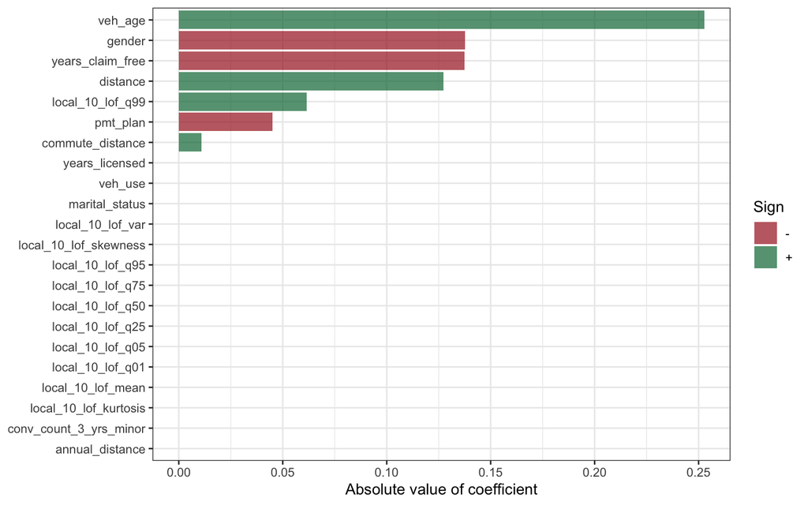

```r
plot_enet_coefs(glmnet_last_fit_ls[[5]])
```

#### class + dist + global_10_lof

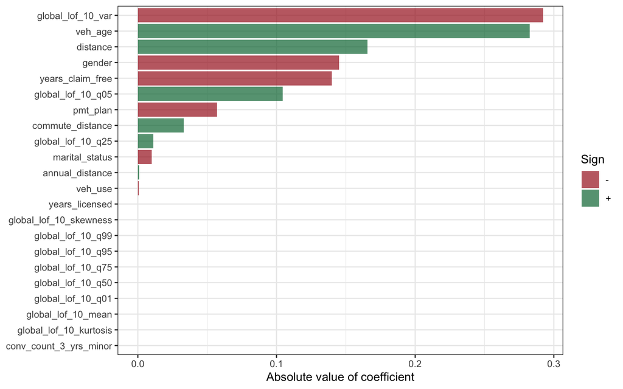

```r
plot_enet_coefs(glmnet_last_fit_ls[[6]])
```

#### class + dist + global_20_lof

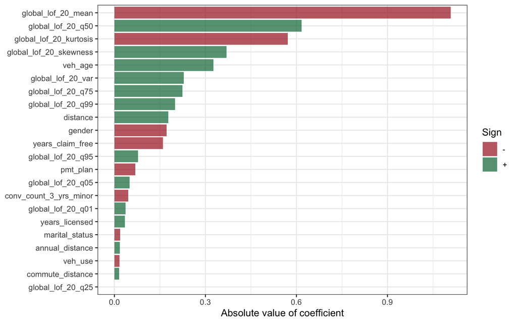

```r
plot_enet_coefs(glmnet_last_fit_ls[[7]])
```

#### class + dist + global_30_lof

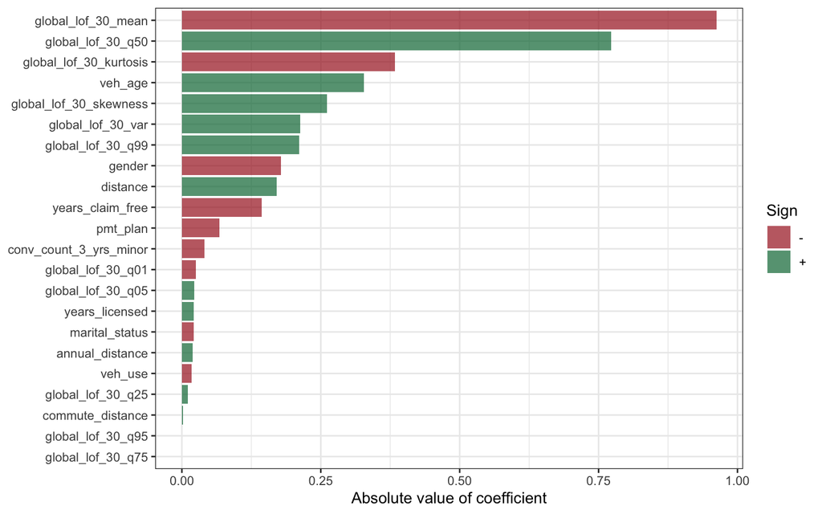

```r
plot_enet_coefs(glmnet_last_fit_ls[[8]])
```

#### class + dist + global_40_lof

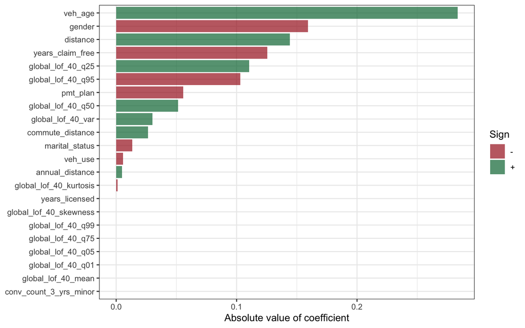

```r
plot_enet_coefs(glmnet_last_fit_ls[[9]])
```

## 3.2 Modèles random forest

### 3.2.1 Performance avec 25 échantillons bootstrap

#### AUC

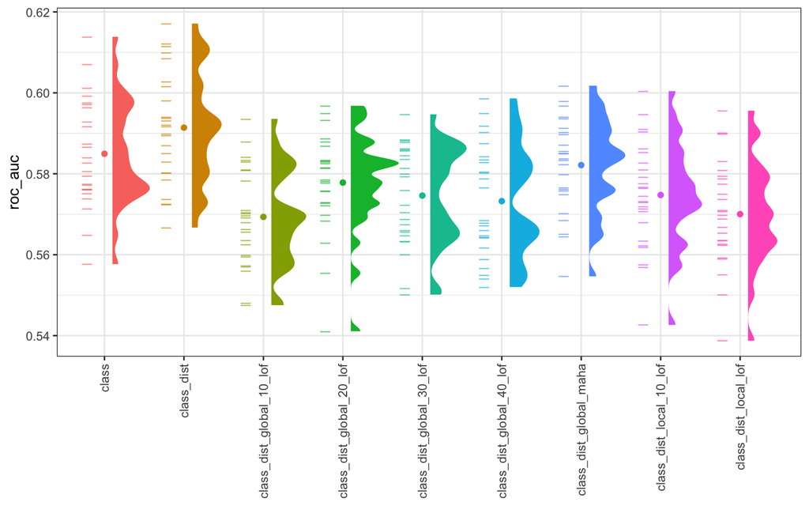

```r
make_plot("roc_auc", rf_res, rf_res_sum)
```

#### Accuracy

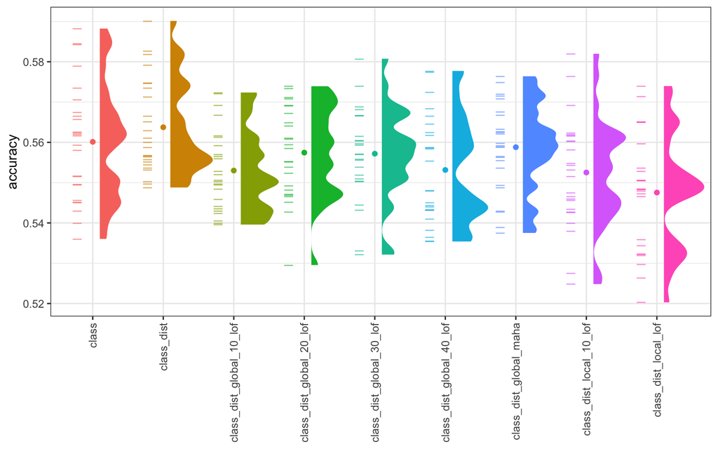

```r
make_plot("accuracy", rf_res, rf_res_sum)
```

#### Sensibilité

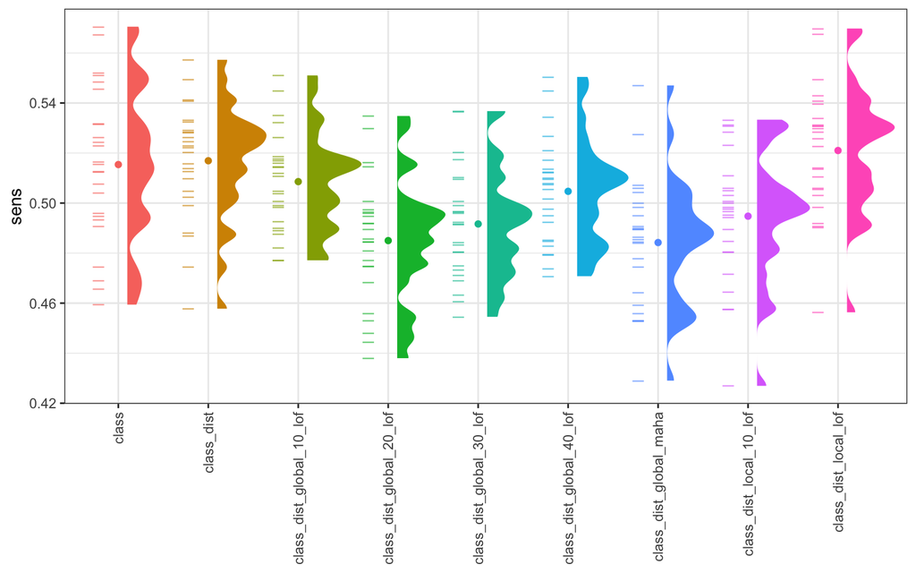

```r
make_plot("sens", rf_res, rf_res_sum)
```

#### Spécificité

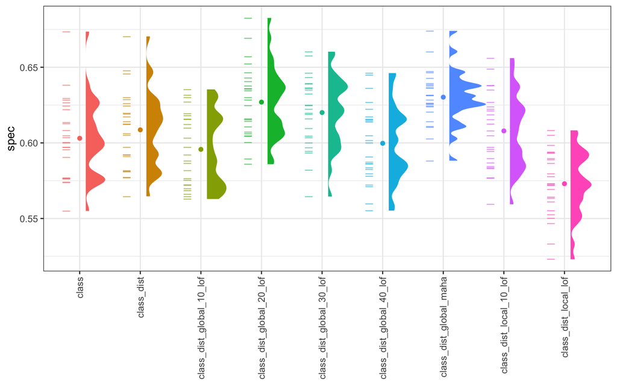

```r
make_plot("spec", rf_res, rf_res_sum)
```

### 3.2.2 Amélioration par rapport au modèle classique

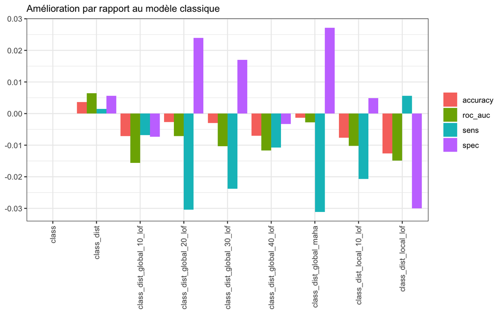

```r
rf_res_sum %>%
  group_split(.metric) %>%
  map(~ mutate(., amelioration = mean - first(mean))) %>%
  reduce(bind_rows) %>%
  ggplot(aes(y = amelioration, x = covariates, fill = .metric)) +
  geom_col(position = "dodge") +
  theme(axis.text.x = element_text(angle = 90, vjust = 0.5, hjust = 1)) +
  xlab(NULL) +
  ylab(NULL) +
  labs(fill = NULL, subtitle = "Amélioration par rapport au modèle classique")
```

### 3.2.3 Amélioration par rapport au modèle classique + distance

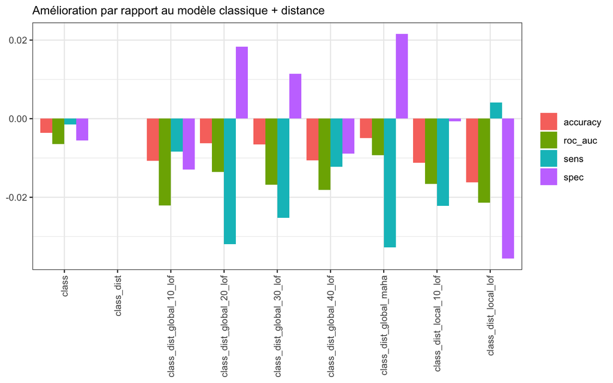

```r
rf_res_sum %>%
  group_split(.metric) %>%
  map(~ mutate(., amelioration = mean - nth(mean, 2))) %>%
  reduce(bind_rows) %>%
  ggplot(aes(y = amelioration, x = covariates, fill = .metric)) +
  geom_col(position = "dodge") +
  theme(axis.text.x = element_text(angle = 90, vjust = 0.5, hjust = 1)) +
  xlab(NULL) +
  ylab(NULL) +
  labs(fill = NULL, subtitle = "Amélioration par rapport au modèle classique + distance")
```

## 3.3 Modèles XGBoost

### 3.3.1 Performance avec 25 échantillons bootstrap

#### AUC

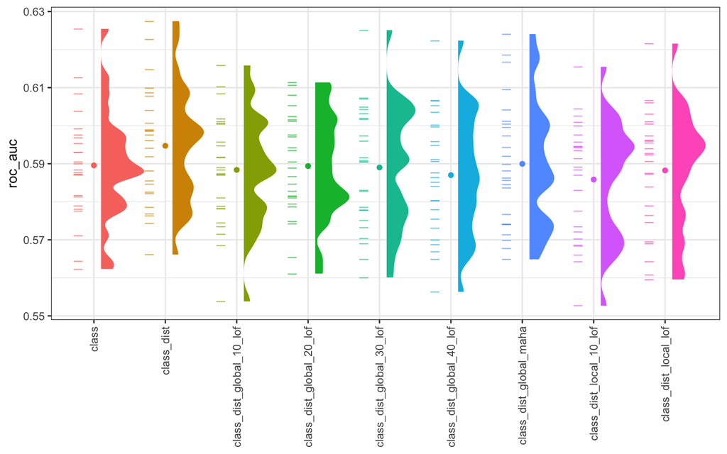

```r
make_plot("roc_auc", xgb_res, xgb_res_sum)
```

#### Accuracy

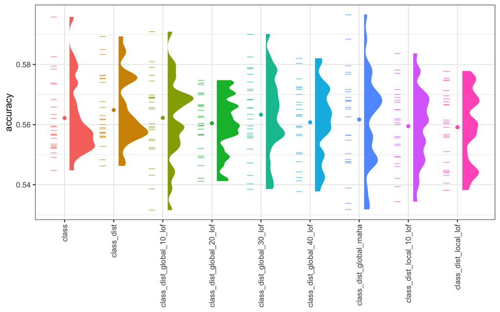

```r
make_plot("accuracy", xgb_res, xgb_res_sum)
```

#### Sensibilité

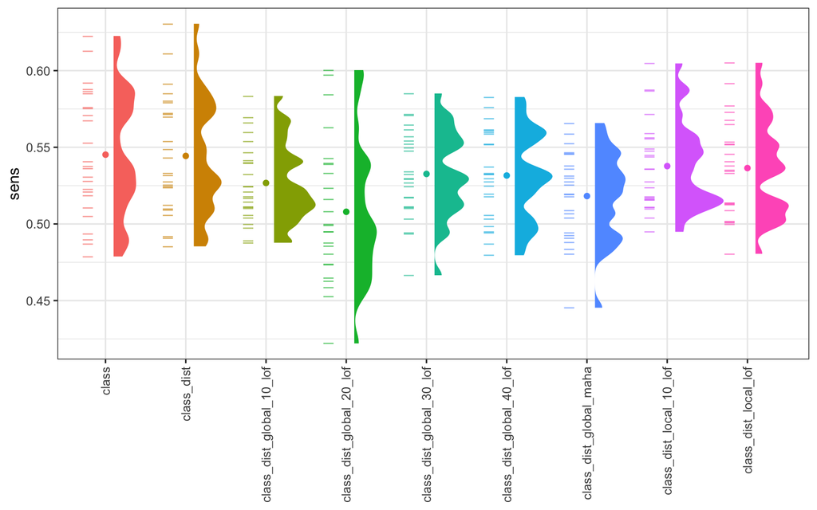

```r
make_plot("sens", xgb_res, xgb_res_sum)
```

#### Spécificité

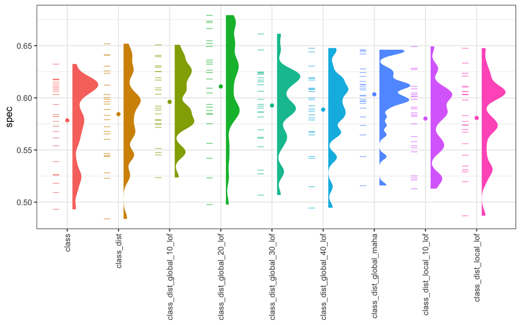

```r
make_plot("spec", xgb_res, xgb_res_sum)
```

### 3.3.2 Amélioration par rapport au modèle classique

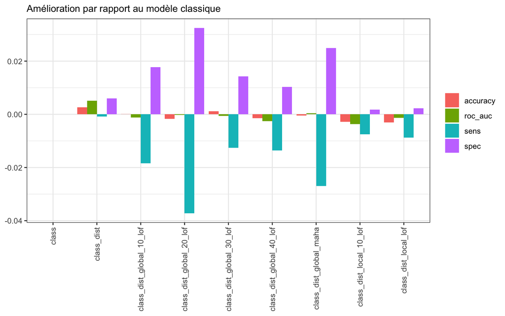

```r
xgb_res_sum %>%
  group_split(.metric) %>%
  map(~ mutate(., amelioration = mean - first(mean))) %>%
  reduce(bind_rows) %>%
  ggplot(aes(y = amelioration, x = covariates, fill = .metric)) +
  geom_col(position = "dodge") +
  theme(axis.text.x = element_text(angle = 90, vjust = 0.5, hjust = 1)) +
  xlab(NULL) +
  ylab(NULL) +
  labs(fill = NULL, subtitle = "Amélioration par rapport au modèle classique")
```